# Decorrelation-Based Feature Discovery: NHNES

Jose Tamez

2023-09-18

# 1 Effect of UPSTM-Based Decorrelation on Feature Discovery

### 1.0.1 Loading the libraries

```r
library("FRESA.CAD")
library(readxl)
library(igraph)
library(umap)
library(tsne)
library(entropy)

op <- par(no.readonly = TRUE)
pander::panderOptions('digits', 3)
pander::panderOptions('table.split.table', 400)
pander::panderOptions('keep.trailing.zeros',TRUE)
```

## 1.1 Material and Methods

## 1.2 The Data

Data source:

https://www.kaggle.com/datasets/cdc/national-health-and-nutrition-examination-survey?select=labs.csv

Details:

https://www.cdc.gov/Nchs/Nhanes/about_nhanes.htm

```r
demographic <- as.data.frame(read_excel("~/GitHub/LatentBiomarkers/Data/NHNES/demographic.xlsx"))
demographiDesc <- as.data.frame(read_excel("~/GitHub/LatentBiomarkers/Data/NHNES/demographic.xlsx",sheet = "Sheet1"))

rownames(demographic) <- demographic$SEQN
demographic$SEQN <- NULL

vartokeep <- demographiDesc[demographiDesc$Keep=="Yes",1]
demographic <- demographic[,vartokeep]

keepColumn <- apply(!is.na(demographic),2,sum)/nrow(demographic) > 0.75
demographic <- demographic[,keepColumn]
demographic <- demographic[complete.cases(demographic),]

## Examination data
examination <- as.data.frame(read_excel("~/GitHub/LatentBiomarkers/Data/NHNES/examination.xlsx"))
examinationDesc <- as.data.frame(read_excel("~/GitHub/LatentBiomarkers/Data/NHNES/examination.xlsx",sheet = "Sheet1"))
rownames(examination) <- examination$SEQN
examination$SEQN <- NULL

bpresDI <- examination[,c("BPXDI1","BPXDI2","BPXDI3","BPXDI4")]
examination[,c("BPXDI1","BPXDI2","BPXDI3","BPXDI4")] <- NULL
bpresDIM <- apply(bpresDI,1,mean,na.rm=TRUE)
summary(bpresDIM)
```

```
#>    Min. 1st Qu.  Median    Mean 3rd Qu.    Max.    NA's
#>    0.00   58.00   66.67   65.44   74.67  128.00    2282
```

```r
bpresSY <- examination[,c("BPXSY1","BPXSY2","BPXSY3","BPXSY4")]
examination[,c("BPXSY1","BPXSY2","BPXSY3","BPXSY4")] <- NULL
bpresSYM <- apply(bpresSY,1,mean,na.rm=TRUE)
summary(bpresSYM)
```

```
#>    Min. 1st Qu.  Median    Mean 3rd Qu.    Max.    NA's
#>   64.67  106.00  115.33  118.31  128.00  228.67    2282
```

```r
examination$PEASCST1 <- NULL
examination$bpresDIM <- bpresDIM
examination$bpresSYM <- bpresSYM

keepColumn <- apply(!is.na(examination),2,sum)/nrow(examination) > 0.75
examination <- examination[,keepColumn]
keepColumnVar <- !is.na(apply(examination,2,var,na.rm = TRUE))
examination <- examination[,keepColumnVar]
examination <- examination[complete.cases(examination),]
examination <- examination[examination$bpresDIM>0,]



## questionnaire data
questionnaire <- as.data.frame(read_excel("~/GitHub/LatentBiomarkers/Data/NHNES/questionnaire.xlsx"))
questionnaireDesc <- as.data.frame(read_excel("~/GitHub/LatentBiomarkers/Data/NHNES/questionnaire.xlsx",sheet = "Sheet1"))
rownames(questionnaire) <- questionnaire$SEQN
questionnaire$SEQN <- NULL
table(questionnaire$MCQ010)
```

```
#>
#>    1    2    7    9
#> 1538 8222    1    8
```

```r
#keepColumn <- apply(!is.na(questionnaire),2,sum)/nrow(questionnaire) > 0.85
#questionnaire <- questionnaire[,keepColumn]
#keepColumnVar <- !is.na(apply(questionnaire,2,var,na.rm = TRUE))
#questionnaire <- questionnaire[,keepColumnVar]
#questionnaire <- questionnaire[complete.cases(questionnaire),]
#keeprow <- apply(questionnaire,2,max) < 9000
#questionnaire <- questionnaire[keeprow,]
#table(questionnaire$MCQ010)

## Diabetes
Diabetes <- questionnaire$MCQ010
names(Diabetes) <- rownames(questionnaire)
Diabetes <- Diabetes[!is.na(Diabetes)]
Diabetes <- Diabetes[Diabetes<3]
table(Diabetes)
```

```
#> Diabetes
#>    1    2
#> 1538 8222
```

```r
## Depression
depression <- questionnaire[,c("DPQ010","DPQ020","DPQ030","DPQ040","DPQ050","DPQ060","DPQ070","DPQ080","DPQ090")]
depression[depression>5] <- "NA"
depressionTot <- apply(depression>0,1,sum,na.rm=TRUE) > 0
donnow <- apply(is.na(depression),1,sum) == 9
table(depressionTot)
```

```
#> depressionTot
#> FALSE  TRUE
#>  6491  3684
```

```r
depressionTot <- depressionTot[!donnow]
table(depressionTot)
```

```
#> depressionTot
#> FALSE  TRUE
#>  1714  3684
```

```r
## The labs data
labs <- as.data.frame(read_excel("~/GitHub/LatentBiomarkers/Data/NHNES/labs.xlsx"))
labsDesc <- as.data.frame(read_excel("~/GitHub/LatentBiomarkers/Data/NHNES/labs.xlsx",sheet = "Sheet1"))

rownames(labs) <- labs$SEQN
labs$SEQN <- NULL

keepColumn <- apply(!is.na(labs),2,sum)/nrow(labs) > 0.75
labs <- labs[,keepColumn]
keepColumnVar <- !is.na(apply(labs,2,var,na.rm = TRUE))
labs <- labs[,keepColumnVar]
labs <- labs[complete.cases(labs),]

includeIDS <- rownames(labs)[rownames(labs) %in% rownames(examination)]
includeIDS <- includeIDS[includeIDS %in% rownames(demographic)]

includeIDS <- includeIDS[includeIDS %in% names(Diabetes)]

Diab <- Diabetes[includeIDS]
table(Diab)
```

```
#> Diab
#>    1    2
#>  992 5006
```

```r
NHNES <- cbind(demographic[includeIDS,],examination[includeIDS,],labs[includeIDS,])
NHNES$Diab <- Diab

table(NHNES$Diab)
```

```
#>
#>    1    2
#>  992 5006
```

```r
NHNES <- NHNES[NHNES$RIDAGEYR >= 20,]

NHNES$Diab <- 1*(NHNES$Diab == 1)

table(NHNES$Diab)
```

```
#>
#>    0    1
#> 3664  650
```

```r
includeIDS <- rownames(NHNES)
includeIDS <- includeIDS[includeIDS %in% names(depressionTot)]
depressionTot <- depressionTot[includeIDS]
NHNESDep <- cbind(NHNES[includeIDS,],depressionTot)

NHNESDep$depressionTot <- 1*NHNESDep$depressionTot

tbdep <- table(NHNESDep$depressionTot)
genderDiab <- NHNESDep[,c("RIAGENDR","Diab","depressionTot")]

isContinuous <- sapply(apply(NHNESDep,2,unique),length) > 4
sum(isContinuous)
```

```
#> [1] 62
```

```r
NHNESDep <- cbind(NHNESDep[,isContinuous],genderDiab)

table(NHNESDep$depressionTot)
```

```
#>
#>    0    1
#> 1366 2788
```

```r
colnames(NHNESDep)[sapply(apply(NHNESDep,2,unique),length) < 10]
```

```
#>  [1] "OHX04TC"       "OHX06TC"       "OHX10TC"       "OHX11TC"
#>  [5] "OHX13TC"       "OHX20TC"       "OHX25TC"       "OHX29TC"
#>  [9] "LBDBANO"       "RIAGENDR"      "Diab"          "depressionTot"
```

#### 1.2.0.1 Standarize the names for the reporting

```r
studyName <- "NHNES"
dataframe <- NHNESDep
outcome <- "depressionTot"

TopVariables <- 10

thro <- 0.40
cexheat = 0.15
```

## 1.3 Generaring the report

### 1.3.1 Libraries

Some libraries

```r
library(psych)
library(whitening)
library("vioplot")
library("rpart")
```

### 1.3.2 Data specs

```r
pander::pander(c(rows=nrow(dataframe),col=ncol(dataframe)-1))
```

| rows | col |
| --- | --- |
| 4154 | 64 |

```r
pander::pander(table(dataframe[,outcome]))
```

| 0 | 1 |
| --- | --- |
| 1366 | 2788 |

```r
varlist <- colnames(dataframe)
varlist <- varlist[varlist != outcome]

largeSet <- length(varlist) > 1500
```

### 1.3.3 Scaling the data

Scaling and removing near zero variance columns and highly co-linear(r>0.99999) columns

```r
  ### Some global cleaning
  sdiszero <- apply(dataframe,2,sd) > 1.0e-16
  dataframe <- dataframe[,sdiszero]

  varlist <- colnames(dataframe)[colnames(dataframe) != outcome]
  tokeep <- c(as.character(correlated_Remove(dataframe,varlist,thr=0.99999)),outcome)
  dataframe <- dataframe[,tokeep]

  varlist <- colnames(dataframe)
  varlist <- varlist[varlist != outcome]

  iscontinous <- sapply(apply(dataframe,2,unique),length) >= 5 ## Only variables with enough samples



dataframeScaled <- FRESAScale(dataframe,method="OrderLogit")$scaledData
```

## 1.4 The heatmap of the data

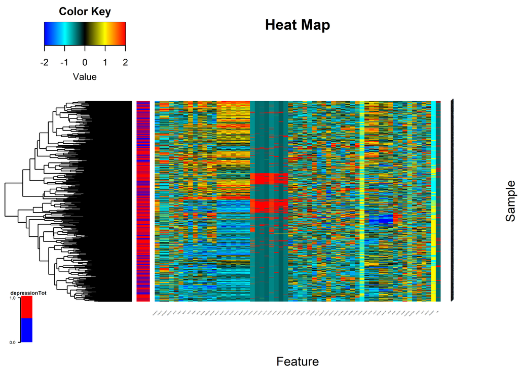

```r
numsub <- nrow(dataframe)
if (numsub > 1000) numsub <- 1000


if (!largeSet)
{

  hm <- heatMaps(data=dataframeScaled[1:numsub,],
                 Outcome=outcome,
                 Scale=TRUE,
                 hCluster = "row",
                 xlab="Feature",
                 ylab="Sample",
                 srtCol=45,
                 srtRow=45,
                 cexCol=cexheat,
                 cexRow=cexheat
                 )
  par(op)
}
```

#### 1.4.0.1 Correlation Matrix of the Data

The heat map of the data

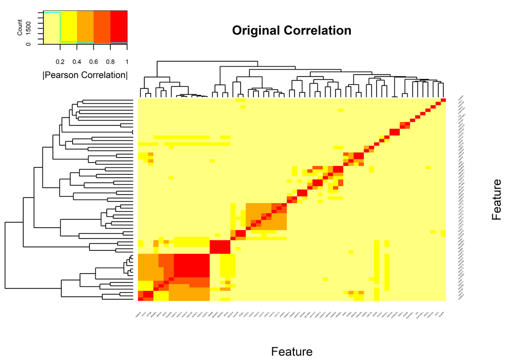

```r
if (!largeSet)
{

  par(cex=0.6,cex.main=0.85,cex.axis=0.7)
  #cormat <- Rfast::cora(as.matrix(dataframe[,varlist]),large=TRUE)
  cormat <- cor(dataframe[,varlist],method="pearson")
  cormat[is.na(cormat)] <- 0
  gplots::heatmap.2(abs(cormat),
                    trace = "none",
  #                  scale = "row",
                    mar = c(5,5),
                    col=rev(heat.colors(5)),
                    main = "Original Correlation",
                    cexRow = cexheat,
                    cexCol = cexheat,
                     srtCol=45,
                     srtRow=45,
                    key.title=NA,
                    key.xlab="|Pearson Correlation|",
                    xlab="Feature", ylab="Feature")
  diag(cormat) <- 0
  print(max(abs(cormat)))
}
```

[1] 0.998876

## 1.5 The decorrelation

```r
DEdataframe <- IDeA(dataframe,verbose=TRUE,thr=thro)
```

```
#>
#>  Included: 57 , Uni p: 0.01178862 , Uncorrelated Base: 13 , Outcome-Driven Size: 0 , Base Size: 13
#>
#>
```

```r
 1 <R=0.999,thr=0.900,N=   17>, Top: 6( 1 )[ 1 : 6 Fa= 6 : 0.900 ]( 6 , 11 , 0 ),<|>Tot Used: 17 , Added: 11 , Zero Std: 0 , Max Cor: 0.930
 2 <R=0.930,thr=0.900,N=   17>, Top: 1( 1 )[ 1 : 1 Fa= 7 : 0.900 ]( 1 , 1 , 6 ),<|>Tot Used: 18 , Added: 1 , Zero Std: 0 , Max Cor: 0.934
 3 <R=0.934,thr=0.900,N=   17>, Top: 1( 1 )[ 1 : 1 Fa= 7 : 0.900 ]( 1 , 1 , 7 ),<|>Tot Used: 18 , Added: 1 , Zero Std: 0 , Max Cor: 0.897
 4 <R=0.897,thr=0.750,N=   20>, Top: 9( 2 )[ 1 : 9 Fa= 15 : 0.750 ]( 9 , 11 , 7 ),<|>Tot Used: 34 , Added: 11 , Zero Std: 0 , Max Cor: 0.980
 5 <R=0.980,thr=0.900,N=    2>, Top: 1( 1 )[ 1 : 1 Fa= 15 : 0.900 ]( 1 , 1 , 15 ),<|>Tot Used: 34 , Added: 1 , Zero Std: 0 , Max Cor: 0.867
 6 <R=0.867,thr=0.750,N=    7>, Top: 3( 1 )[ 1 : 3 Fa= 16 : 0.750 ]( 3 , 3 , 15 ),<|>Tot Used: 35 , Added: 3 , Zero Std: 0 , Max Cor: 0.774
 7 <R=0.774,thr=0.750,N=    7>, Top: 1( 1 )[ 1 : 1 Fa= 16 : 0.750 ]( 1 , 1 , 16 ),<|>Tot Used: 35 , Added: 1 , Zero Std: 0 , Max Cor: 0.719
 8 <R=0.719,thr=0.600,N=   19>, Top: 8( 1 )[ 1 : 8 Fa= 20 : 0.600 ]( 8 , 10 , 16 ),<|>Tot Used: 43 , Added: 10 , Zero Std: 0 , Max Cor: 0.847
 9 <R=0.847,thr=0.750,N=    6>, Top: 3( 1 )[ 1 : 3 Fa= 20 : 0.750 ]( 3 , 3 , 20 ),<|>Tot Used: 43 , Added: 3 , Zero Std: 0 , Max Cor: 0.888
 10 <R=0.888,thr=0.750,N=    6>, Top: 2( 1 )[ 1 : 2 Fa= 21 : 0.750 ]( 2 , 2 , 20 ),<|>Tot Used: 43 , Added: 2 , Zero Std: 0 , Max Cor: 0.748
 11 <R=0.748,thr=0.600,N=    4>, Top: 2( 1 )[ 1 : 2 Fa= 21 : 0.600 ]( 2 , 2 , 21 ),<|>Tot Used: 43 , Added: 2 , Zero Std: 0 , Max Cor: 0.774
 12 <R=0.774,thr=0.750,N=    2>, Top: 1( 1 )[ 1 : 1 Fa= 22 : 0.750 ]( 1 , 1 , 21 ),<|>Tot Used: 44 , Added: 1 , Zero Std: 0 , Max Cor: 0.747
 13 <R=0.747,thr=0.600,N=    2>, Top: 1( 1 )[ 1 : 1 Fa= 22 : 0.600 ]( 1 , 1 , 22 ),<|>Tot Used: 44 , Added: 1 , Zero Std: 0 , Max Cor: 0.592
 14 <R=0.592,thr=0.450,N=   23>, Top: 6( 3 )[ 1 : 6 Fa= 24 : 0.450 ]( 6 , 15 , 22 ),<|>Tot Used: 47 , Added: 15 , Zero Std: 0 , Max Cor: 0.848
 15 <R=0.848,thr=0.750,N=    2>, Top: 1( 1 )[ 1 : 1 Fa= 24 : 0.750 ]( 1 , 1 , 24 ),<|>Tot Used: 47 , Added: 1 , Zero Std: 0 , Max Cor: 0.586
 16 <R=0.586,thr=0.450,N=    8>, Top: 4( 1 )[ 1 : 4 Fa= 25 : 0.450 ]( 4 , 4 , 24 ),<|>Tot Used: 47 , Added: 4 , Zero Std: 0 , Max Cor: 0.449
 17 <R=0.449,thr=0.400,N=   10>, Top: 5( 1 )[ 1 : 5 Fa= 27 : 0.400 ]( 5 , 5 , 25 ),<|>Tot Used: 49 , Added: 5 , Zero Std: 0 , Max Cor: 0.462
 18 <R=0.462,thr=0.450,N=    2>, Top: 1( 1 )[ 1 : 1 Fa= 27 : 0.450 ]( 1 , 1 , 27 ),<|>Tot Used: 49 , Added: 1 , Zero Std: 0 , Max Cor: 0.379
 19 <R=0.379,thr=0.400,N=    0>
 [ 19 ], 0.3787756 Decor Dimension: 49 Nused: 49 . Cor to Base: 25 , ABase: 8 , Outcome Base: 0
varlistc <- colnames(DEdataframe)[colnames(DEdataframe) != outcome]

pander::pander(sum(apply(dataframe[,varlist],2,var)))
```

*1.98e+09*

```r
pander::pander(sum(apply(DEdataframe[,varlistc],2,var)))
```

*9.69e+08*

```r
pander::pander(entropy(discretize(unlist(dataframe[,varlist]), 256)))
```

*0.377*

```r
pander::pander(entropy(discretize(unlist(DEdataframe[,varlistc]), 256)))
```

*0.336*

### 1.5.1 The decorrelation matrix

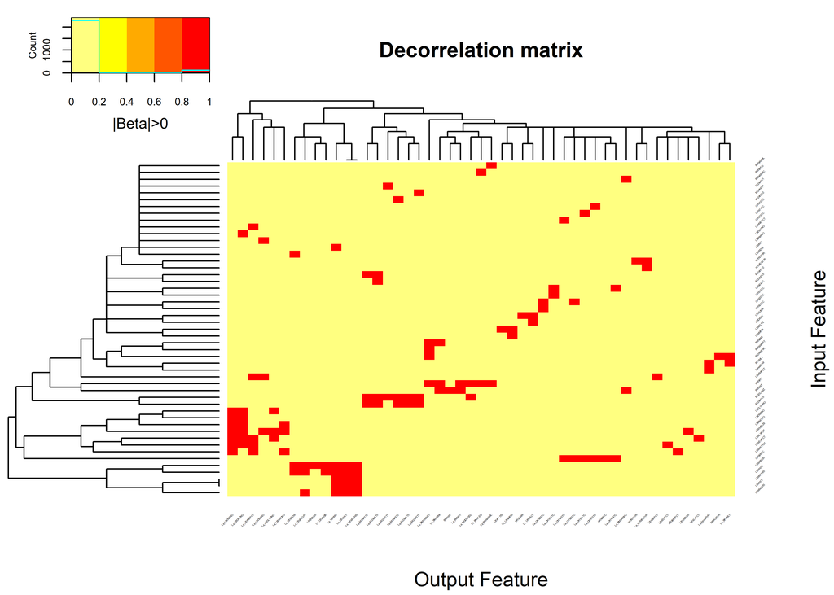

```r
if (!largeSet)
{

  par(cex=0.6,cex.main=0.85,cex.axis=0.7)

  UPSTM <- attr(DEdataframe,"UPSTM")

  gplots::heatmap.2(1.0*(abs(UPSTM)>0),
                    trace = "none",
                    mar = c(5,5),
                    col=rev(heat.colors(5)),
                    main = "Decorrelation matrix",
                    cexRow = cexheat,
                    cexCol = cexheat,
                   srtCol=45,
                   srtRow=45,
                    key.title=NA,
                    key.xlab="|Beta|>0",
                    xlab="Output Feature", ylab="Input Feature")

  par(op)
}
```

## 1.6 The heatmap of the decorrelated data

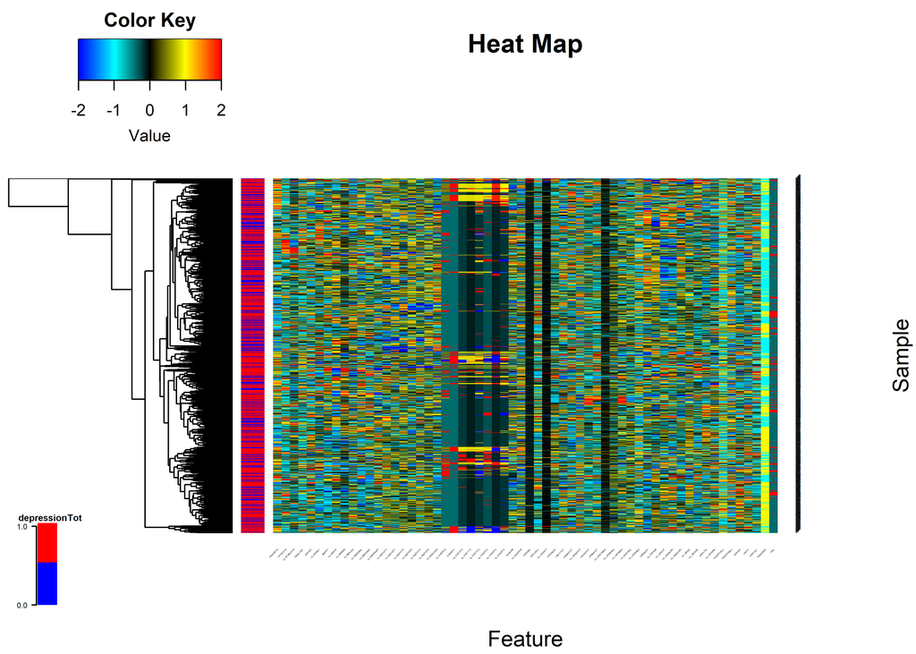

```r
if (!largeSet)
{

  hm <- heatMaps(data=DEdataframe[1:numsub,],
                 Outcome=outcome,
                 Scale=TRUE,
                 hCluster = "row",
                 cexRow = cexheat,
                 cexCol = cexheat,
                 srtCol=45,
                 srtRow=45,
                 xlab="Feature",
                 ylab="Sample")
  par(op)
}
```

## 1.7 The correlation matrix after decorrelation

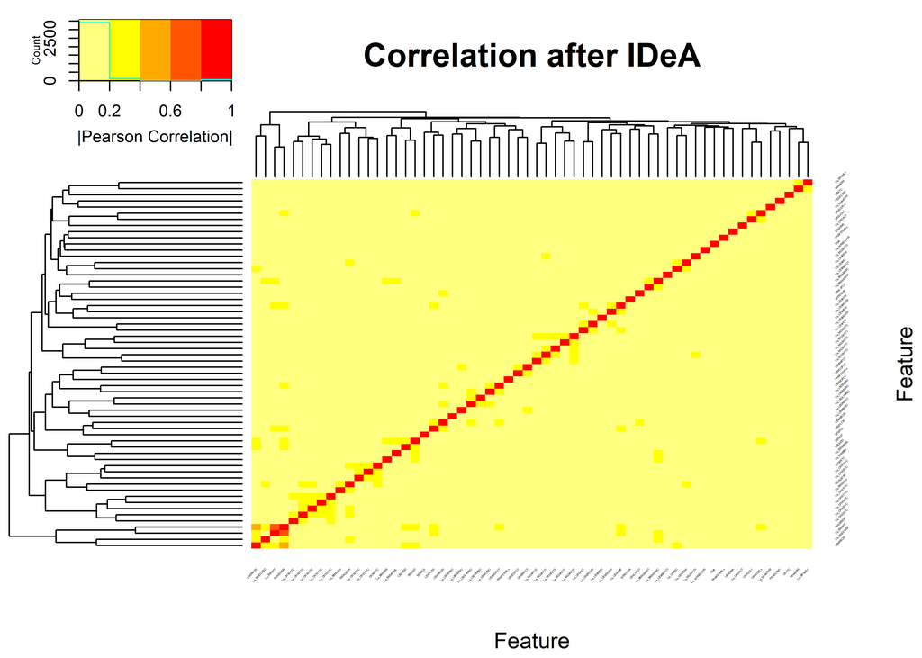

```r
if (!largeSet)
{

  cormat <- cor(DEdataframe[,varlistc],method="pearson")
  cormat[is.na(cormat)] <- 0

  gplots::heatmap.2(abs(cormat),
                    trace = "none",
                    mar = c(5,5),
                    col=rev(heat.colors(5)),
                    main = "Correlation after IDeA",
                    cexRow = cexheat,
                    cexCol = cexheat,
                     srtCol=45,
                     srtRow=45,
                    key.title=NA,
                    key.xlab="|Pearson Correlation|",
                    xlab="Feature", ylab="Feature")

  par(op)
  diag(cormat) <- 0
  print(max(abs(cormat)))
}
```

[1] 0.6389896

## 1.8 U-MAP Visualization of features

### 1.8.1 The UMAP based on LASSO on Raw Data

```r
if (nrow(dataframe) < 1000)
{
  classes <- unique(dataframe[1:numsub,outcome])
  raincolors <- rainbow(length(classes))
  names(raincolors) <- classes
  datasetframe.umap = umap(scale(dataframe[1:numsub,varlist]),n_components=2)
  plot(datasetframe.umap$layout,xlab="U1",ylab="U2",main="UMAP: Original",t='n')
  text(datasetframe.umap$layout,labels=dataframe[1:numsub,outcome],col=raincolors[dataframe[1:numsub,outcome]+1])
}
```

### 1.8.2 The decorralted UMAP

```r
if (nrow(dataframe) < 1000)
{

  datasetframe.umap = umap(scale(DEdataframe[1:numsub,varlistc]),n_components=2)
  plot(datasetframe.umap$layout,xlab="U1",ylab="U2",main="UMAP: After IDeA",t='n')
  text(datasetframe.umap$layout,labels=DEdataframe[1:numsub,outcome],col=raincolors[DEdataframe[1:numsub,outcome]+1])
}
```

## 1.9 Univariate Analysis

### 1.9.1 Univariate

```r
univarRAW <- uniRankVar(varlist,
               paste(outcome,"~1"),
               outcome,
               dataframe,
               rankingTest="AUC")



univarDe <- uniRankVar(varlistc,
               paste(outcome,"~1"),
               outcome,
               DEdataframe,
               rankingTest="AUC",
               )
```

### 1.9.2 Final Table

```r
univariate_columns <- c("caseMean","caseStd","controlMean","controlStd","controlKSP","ROCAUC")

##top variables
topvar <- c(1:length(varlist)) <= TopVariables
tableRaw <- univarRAW$orderframe[topvar,univariate_columns]
pander::pander(tableRaw)
```

|  | caseMean | caseStd | controlMean | controlStd | controlKSP | ROCAUC |
| --- | --- | --- | --- | --- | --- | --- |
| **MGXH1T1** | 31.6 | 10.26 | 34.9 | 10.23 | 6.54e-03 | 0.595 |
| **MGXH1T3** | 33.8 | 10.98 | 37.2 | 10.94 | 9.91e-05 | 0.593 |
| **MGXH1T2** | 33.2 | 10.75 | 36.5 | 10.76 | 1.96e-04 | 0.591 |
| **MGDCGSZ** | 69.9 | 21.87 | 76.5 | 21.69 | 3.38e-05 | 0.590 |
| **MGXH2T3** | 34.1 | 11.13 | 37.3 | 10.97 | 9.25e-05 | 0.588 |
| **MGXH2T1** | 32.4 | 10.65 | 35.5 | 10.53 | 4.61e-04 | 0.587 |
| **MGXH2T2** | 33.7 | 11.04 | 36.9 | 10.95 | 1.99e-05 | 0.586 |
| **RIAGENDR** | 1232.0 | 1556.00 | 828.0 | 538.00 | NA | 0.582 |
| **BMXLEG** | 38.8 | 3.77 | 39.6 | 3.73 | 4.84e-01 | 0.559 |
| **BMXHT** | 167.1 | 9.96 | 169.2 | 10.14 | 7.38e-02 | 0.559 |

```r
topLAvar <- univarDe$orderframe$Name[str_detect(univarDe$orderframe$Name,"La_")]
topLAvar <- unique(c(univarDe$orderframe$Name[topvar],topLAvar[1:as.integer(TopVariables/2)]))
finalTable <- univarDe$orderframe[topLAvar,univariate_columns]


pander::pander(finalTable)
```

|  | caseMean | caseStd | controlMean | controlStd | controlKSP | ROCAUC |
| --- | --- | --- | --- | --- | --- | --- |
| **RIAGENDR** | 1232.000 | 1556.00 | 828.000 | 538.000 | NA | 0.582 |
| **La_BMXHT** | 149.741 | 9.03 | 151.827 | 8.833 | 9.78e-01 | 0.568 |
| **La_MGDCGSZ** | -193.284 | 14.98 | -189.867 | 15.712 | 1.53e-01 | 0.564 |
| **LBXRBCSI** | 4.650 | 0.49 | 4.719 | 0.461 | 2.92e-01 | 0.545 |
| **BPXPLS** | 72.836 | 11.61 | 71.410 | 11.520 | 6.51e-09 | 0.540 |
| **LBXPLTSI** | 237.664 | 60.65 | 230.102 | 58.465 | 1.64e-03 | 0.538 |
| **LBXMOPCT** | 8.130 | 2.28 | 8.373 | 2.209 | 2.59e-06 | 0.537 |
| **La_MGXH1T1** | 0.760 | 3.56 | 1.123 | 3.699 | 2.19e-06 | 0.537 |
| **Diab** | 2297.000 | 491.00 | 1221.000 | 145.000 | NA | 0.535 |
| **LBXWBCSI** | 7.410 | 2.39 | 7.133 | 2.087 | 3.29e-08 | 0.534 |
| **La_LBXHGB** | 3.941 | 1.07 | 4.013 | 1.064 | 1.29e-11 | 0.528 |
| **La_MGXH1T3** | -0.342 | 2.73 | -0.111 | 2.626 | 9.96e-04 | 0.526 |

```r
dc <- getLatentCoefficients(DEdataframe)
fscores <- attr(DEdataframe,"fscore")


pander::pander(c(mean=mean(sapply(dc,length)),total=length(dc),fraction=length(dc)/(ncol(dataframe)-1)))
```

| mean | total | fraction |
| --- | --- | --- |
| 2.97 | 37 | 0.617 |

```r
theCharformulas <- attr(dc,"LatentCharFormulas")


finalTable <- rbind(finalTable,tableRaw[topvar[!(topvar %in% topLAvar)],univariate_columns])


orgnamez <- rownames(finalTable)
orgnamez <- str_remove_all(orgnamez,"La_")
finalTable$RAWAUC <- univarRAW$orderframe[orgnamez,"ROCAUC"]
finalTable$DecorFormula <- theCharformulas[rownames(finalTable)]
finalTable$fscores <- fscores[rownames(finalTable)]

Final_Columns <- c("DecorFormula","caseMean","caseStd","controlMean","controlStd","controlKSP","ROCAUC","RAWAUC","fscores")

finalTable <- finalTable[order(-finalTable$ROCAUC),]
pander::pander(finalTable[,Final_Columns])
```

|  | DecorFormula | caseMean | caseStd | controlMean | controlStd | controlKSP | ROCAUC | RAWAUC | fscores |
| --- | --- | --- | --- | --- | --- | --- | --- | --- | --- |
| **MGXH1T1** | NA | 31.582 | 10.26 | 34.884 | 10.232 | 6.54e-03 | 0.595 | 0.595 | NA |
| **MGXH1T3** | NA | 33.754 | 10.98 | 37.236 | 10.937 | 9.91e-05 | 0.593 | 0.593 | NA |
| **MGXH1T2** | NA | 33.203 | 10.75 | 36.493 | 10.761 | 1.96e-04 | 0.591 | 0.591 | NA |
| **MGDCGSZ** | NA | 69.865 | 21.87 | 76.526 | 21.694 | 3.38e-05 | 0.590 | 0.590 | NA |
| **MGXH2T3** | NA | 34.100 | 11.13 | 37.350 | 10.971 | 9.25e-05 | 0.588 | 0.588 | NA |
| **MGXH2T1** | NA | 32.444 | 10.65 | 35.517 | 10.530 | 4.61e-04 | 0.587 | 0.587 | NA |
| **MGXH2T2** | NA | 33.741 | 11.04 | 36.930 | 10.955 | 1.99e-05 | 0.586 | 0.586 | NA |
| **RIAGENDR** | NA | 1232.000 | 1556.00 | 828.000 | 538.000 | NA | 0.582 | 0.582 | NA |
| **RIAGENDR1** | NA | 1232.000 | 1556.00 | 828.000 | 538.000 | NA | 0.582 | NA | NA |
| **La_BMXHT** | - (0.212)BMXWT + BMXHT | 149.741 | 9.03 | 151.827 | 8.833 | 9.78e-01 | 0.568 | 0.559 | 5 |
| **La_MGDCGSZ** | - (1.575)BMXHT + MGDCGSZ | -193.284 | 14.98 | -189.867 | 15.712 | 1.53e-01 | 0.564 | 0.590 | 5 |
| **BMXLEG** | NA | 38.848 | 3.77 | 39.616 | 3.727 | 4.84e-01 | 0.559 | 0.559 | NA |
| **BMXHT** | NA | 167.099 | 9.96 | 169.159 | 10.140 | 7.38e-02 | 0.559 | 0.559 | NA |
| **LBXRBCSI** | NA | 4.650 | 0.49 | 4.719 | 0.461 | 2.92e-01 | 0.545 | 0.545 | 3 |
| **BPXPLS** | NA | 72.836 | 11.61 | 71.410 | 11.520 | 6.51e-09 | 0.540 | 0.540 | NA |
| **LBXPLTSI** | NA | 237.664 | 60.65 | 230.102 | 58.465 | 1.64e-03 | 0.538 | 0.538 | 1 |
| **LBXMOPCT** | NA | 8.130 | 2.28 | 8.373 | 2.209 | 2.59e-06 | 0.537 | 0.537 | 4 |
| **La_MGXH1T1** | + MGXH1T1 - (0.441)MGDCGSZ | 0.760 | 3.56 | 1.123 | 3.699 | 2.19e-06 | 0.537 | 0.595 | -1 |
| **Diab** | NA | 2297.000 | 491.00 | 1221.000 | 145.000 | NA | 0.535 | 0.535 | NA |
| **LBXWBCSI** | NA | 7.410 | 2.39 | 7.133 | 2.087 | 3.29e-08 | 0.534 | 0.534 | 7 |
| **La_LBXHGB** | - (2.163)LBXRBCSI + LBXHGB | 3.941 | 1.07 | 4.013 | 1.064 | 1.29e-11 | 0.528 | 0.549 | 3 |
| **La_MGXH1T3** | + MGXH1T3 - (0.488)MGDCGSZ | -0.342 | 2.73 | -0.111 | 2.626 | 9.96e-04 | 0.526 | 0.593 | 3 |

## 1.10 Comparing IDeA vs PCA vs EFA

### 1.10.1 PCA

```r
featuresnames <- colnames(dataframe)[colnames(dataframe) != outcome]
pc <- prcomp(dataframe[,iscontinous],center = TRUE,scale. = TRUE)   #principal components
predPCA <- predict(pc,dataframe[,iscontinous])
PCAdataframe <- as.data.frame(cbind(predPCA,dataframe[,!iscontinous]))
colnames(PCAdataframe) <- c(colnames(predPCA),colnames(dataframe)[!iscontinous])
#plot(PCAdataframe[,colnames(PCAdataframe)!=outcome],col=dataframe[,outcome],cex=0.65,cex.lab=0.5,cex.axis=0.75,cex.sub=0.5,cex.main=0.75)

#pander::pander(pc$rotation)


PCACor <- cor(PCAdataframe[,colnames(PCAdataframe) != outcome])


  gplots::heatmap.2(abs(PCACor),
                    trace = "none",
  #                  scale = "row",
                    mar = c(5,5),
                    col=rev(heat.colors(5)),
                    main = "PCA Correlation",
                    cexRow = 0.5,
                    cexCol = 0.5,
                     srtCol=45,
                     srtRow= -45,
                    key.title=NA,
                    key.xlab="Pearson Correlation",
                    xlab="Feature", ylab="Feature")
```

[figure not shown]

### 1.10.2 EFA

```r
EFAdataframe <- dataframeScaled

if (length(iscontinous) < 2000)
{
  topred <- min(length(iscontinous),nrow(dataframeScaled),ncol(predPCA)/2)
  if (topred < 2) topred <- 2

  uls <- fa(dataframeScaled[,iscontinous],nfactors=topred,rotate="varimax",warnings=FALSE)  # EFA analysis
  predEFA <- predict(uls,dataframeScaled[,iscontinous])
  EFAdataframe <- as.data.frame(cbind(predEFA,dataframeScaled[,!iscontinous]))
  colnames(EFAdataframe) <- c(colnames(predEFA),colnames(dataframeScaled)[!iscontinous])



  EFACor <- cor(EFAdataframe[,colnames(EFAdataframe) != outcome])


    gplots::heatmap.2(abs(EFACor),
                      trace = "none",
    #                  scale = "row",
                      mar = c(5,5),
                      col=rev(heat.colors(5)),
                      main = "EFA Correlation",
                      cexRow = 0.5,
                      cexCol = 0.5,
                       srtCol=45,
                       srtRow= -45,
                      key.title=NA,
                      key.xlab="Pearson Correlation",
                      xlab="Feature", ylab="Feature")
}
```

[figure not shown]

## 1.11 Effect on CAR modeling

```r
par(op)
par(xpd = TRUE)
dataframe[,outcome] <- factor(dataframe[,outcome])
rawmodel <- rpart(paste(outcome,"~."),dataframe,control=rpart.control(maxdepth=3))
pr <- predict(rawmodel,dataframe,type = "class")

  ptab <- list(er="Error",detail=matrix(nrow=6,ncol=1))
  if (length(unique(pr))>1)
  {
    plot(rawmodel,main="Raw",branch=0.5,uniform = TRUE,compress = TRUE,margin=0.1)
    text(rawmodel, use.n = TRUE,cex=0.75)
    ptab <- epiR::epi.tests(table(pr==0,dataframe[,outcome]==0))
  }

pander::pander(table(dataframe[,outcome],pr))
```

|  | 0 | 1 |
| --- | --- | --- |
| **0** | 0 | 1366 |
| **1** | 0 | 2788 |

```r
pander::pander(ptab$detail[c(5,3,4,6),])
```

*NA*, *NA*, *NA* and *NA*

```r
par(op)
par(xpd = TRUE)
DEdataframe[,outcome] <- factor(DEdataframe[,outcome])
IDeAmodel <- rpart(paste(outcome,"~."),DEdataframe,control=rpart.control(maxdepth=3))
pr <- predict(IDeAmodel,DEdataframe,type = "class")

  ptab <- list(er="Error",detail=matrix(nrow=6,ncol=1))
  if (length(unique(pr))>1)
  {
    plot(IDeAmodel,main="IDeA",branch=0.5,uniform = TRUE,compress = TRUE,margin=0.1)
    text(IDeAmodel, use.n = TRUE,cex=0.75)
    ptab <- epiR::epi.tests(table(pr==0,DEdataframe[,outcome]==0))
  }
pander::pander(table(DEdataframe[,outcome],pr))
```

|  | 0 | 1 |
| --- | --- | --- |
| **0** | 0 | 1366 |
| **1** | 0 | 2788 |

```r
pander::pander(ptab$detail[c(5,3,4,6),])
```

*NA*, *NA*, *NA* and *NA*

```r
par(op)
par(xpd = TRUE)
PCAdataframe[,outcome] <- factor(PCAdataframe[,outcome])
PCAmodel <- rpart(paste(outcome,"~."),PCAdataframe,control=rpart.control(maxdepth=3))
pr <- predict(PCAmodel,PCAdataframe,type = "class")
ptab <- list(er="Error",detail=matrix(nrow=6,ncol=1))
if (length(unique(pr))>1)
{
  plot(PCAmodel,main="PCA",branch=0.5,uniform = TRUE,compress = TRUE,margin=0.1)
  text(PCAmodel, use.n = TRUE,cex=0.75)
  ptab <- epiR::epi.tests(table(pr==0,PCAdataframe[,outcome]==0))
}
pander::pander(table(PCAdataframe[,outcome],pr))
```

|  | 0 | 1 |
| --- | --- | --- |
| **0** | 0 | 1366 |
| **1** | 0 | 2788 |

```r
pander::pander(ptab$detail[c(5,3,4,6),])
```

*NA*, *NA*, *NA* and *NA*

```r
par(op)
```

### 1.11.1 EFA

```r
  EFAdataframe[,outcome] <- factor(EFAdataframe[,outcome])
  EFAmodel <- rpart(paste(outcome,"~."),EFAdataframe,control=rpart.control(maxdepth=3))
  pr <- predict(EFAmodel,EFAdataframe,type = "class")

  ptab <- list(er="Error",detail=matrix(nrow=6,ncol=1))
  if (length(unique(pr))>1)
  {
    plot(EFAmodel,main="EFA",branch=0.5,uniform = TRUE,compress = TRUE,margin=0.1)
    text(EFAmodel, use.n = TRUE,cex=0.75)
    ptab <- epiR::epi.tests(table(pr==0,EFAdataframe[,outcome]==0))
  }

  pander::pander(table(EFAdataframe[,outcome],pr))
```

|  | 0 | 1 |
| --- | --- | --- |
| **0** | 0 | 1366 |
| **1** | 0 | 2788 |

```r
  pander::pander(ptab$detail[c(5,3,4,6),])
```

*NA*, *NA*, *NA* and *NA*

```r
  par(op)
```

## 1.12 The Latent formulas

```r
theLaFormulas <- getLatentCoefficients(DEdataframe)


## Add the variable description

allvardes <- rbind(demographiDesc[,1:2],examinationDesc[,1:2],labsDesc[,1:2])
dup <- duplicated(allvardes[,1])
allvardes <- allvardes[!dup,]
rownames(allvardes) <- allvardes[,1]
lavar <-  names(theLaFormulas)[1]
theLaFormulas[[lavar]]
```

```
#>  WTINT2YR  WTMEC2YR
#> -1.024031  1.000000
```

```r
for (lavar in names(theLaFormulas))
{
  theLaFormulas[[lavar]]$Desc <- paste("(",allvardes[names(theLaFormulas[[lavar]]),2],")\n\r",sep="")
}

pander::pander(theLaFormulas)
```

- **La_WTMEC2YR**:
  - **WTINT2YR**: *-1.02*
  - **WTMEC2YR**: *1*
  - **Desc**: _(Full sample 2 year interview weight.)

_ and _(Full sample 2 year MEC exam weight.)

_

- **La_BPXML1**:
  - **RIDAGEYR**: *-0.45*
  - **BPXML1**: *1*
  - **Desc**: _(Age in years of the participant at the time of screening. Individuals 80 and over are topcoded at 80 years of age.)

_ and _(MIL: maximum inflation levels (mm Hg))

_

- **La_BMXHT**:
  - **BMXWT**: *-0.212*
  - **BMXHT**: *1*
  - **Desc**: _(Weight (kg))

_ and _(Standing Height (cm))

_

- **La_BMXBMI**:
  - **BMXWT**: *-0.338*
  - **BMXHT**: *0.332*
  - **BMXBMI**: *1*
  - **Desc**: _(Weight (kg))

*,* (Standing Height (cm))

_ and _(Body Mass Index (kg/m**2))

_

- **La_BMXLEG**:
  - **BMXHT**: *-0.296*
  - **BMXLEG**: *1*
  - **Desc**: _(Standing Height (cm))

_ and _(Upper Leg Length (cm))

_

- **La_BMXARML**:
  - **BMXHT**: *-0.224*
  - **BMXARML**: *1*
  - **Desc**: _(Standing Height (cm))

_ and _(Upper Arm Length (cm))

_

- **La_BMXARMC**:
  - **BMXWT**: *-0.215*
  - **BMXARMC**: *1*
  - **Desc**: _(Weight (kg))

_ and _(Arm Circumference (cm))

_

- **La_BMXWAIST**:
  - **RIDAGEYR**: *-0.162*
  - **BMXHT**: *-0.317*
  - **BMXBMI**: *-2.19*
  - **BMXWAIST**: *1*
  - **Desc**: _(Age in years of the participant at the time of screening. Individuals 80 and over are topcoded at 80 years of age.)

*,* (Standing Height (cm))

*,* (Body Mass Index (kg/m**2))

_ and _(Waist Circumference (cm))

_

- **La_MGXH1T1**:
  - **MGXH1T1**: *1*
  - **MGDCGSZ**: *-0.441*
  - **Desc**: _(Grip strength (kg), hand 1, test 1)

_ and _(Combined grip strength (kg): the sum of the largest reading from each hand.)

_

- **La_MGXH2T1**:
  - **MGXH2T1**: *1*
  - **MGXH1T3**: *0.589*
  - **MGDCGSZ**: *-0.752*
  - **Desc**: _(Grip strength (kg), hand 2, test 1)

*,* (Grip strength (kg), hand 1, test 3)

_ and _(Combined grip strength (kg): the sum of the largest reading from each hand.)

_

- **La_MGXH1T2**:
  - **MGXH1T2**: *1*
  - **MGXH1T3**: *-0.541*
  - **MGDCGSZ**: *-0.211*
  - **Desc**: _(Grip strength (kg), hand 1, test 2)

*,* (Grip strength (kg), hand 1, test 3)

_ and _(Combined grip strength (kg): the sum of the largest reading from each hand.)

_

- **La_MGXH2T2**:
  - **MGXH2T2**: *1*
  - **MGXH1T3**: *0.586*
  - **MGDCGSZ**: *-0.774*
  - **Desc**: _(Grip strength (kg), hand 2, test 2)

*,* (Grip strength (kg), hand 1, test 3)

_ and _(Combined grip strength (kg): the sum of the largest reading from each hand.)

_

- **La_MGXH1T3**:
  - **MGXH1T3**: *1*
  - **MGDCGSZ**: *-0.488*
  - **Desc**: _(Grip strength (kg), hand 1, test 3)

_ and _(Combined grip strength (kg): the sum of the largest reading from each hand.)

_

- **La_MGXH2T3**:
  - **MGXH1T2**: *0.363*
  - **MGXH1T3**: *0.356*
  - **MGXH2T3**: *1*
  - **MGDCGSZ**: *-0.838*
  - **Desc**: _(Grip strength (kg), hand 1, test 2)

*,* (Grip strength (kg), hand 1, test 3)

*,* (Grip strength (kg), hand 2, test 3)

_ and _(Combined grip strength (kg): the sum of the largest reading from each hand.)

_

- **La_MGDCGSZ**:
  - **BMXHT**: *-1.57*
  - **MGDCGSZ**: *1*
  - **Desc**: _(Standing Height (cm))

_ and _(Combined grip strength (kg): the sum of the largest reading from each hand.)

_

- **La_OHX04TC**:
  - **OHX04TC**: *1*
  - **OHX06TC**: *-0.695*
  - **Desc**: _(Tooth Count: Upper right 2nd bicuspid/2nd primary molar (2B))

_ and _(Tooth Count: Upper right cuspid (C))

_

- **La_OHX10TC**:
  - **OHX06TC**: *-0.739*
  - **OHX10TC**: *1*
  - **Desc**: _(Tooth Count: Upper right cuspid (C))

_ and _(Tooth Count: Upper left lateral incisor (LI))

_

- **La_OHX11TC**:
  - **OHX06TC**: *-0.789*
  - **OHX11TC**: *1*
  - **Desc**: _(Tooth Count: Upper right cuspid (C))

_ and _(Tooth Count: Upper left cuspid (C))

_

- **La_OHX13TC**:
  - **OHX04TC**: *-0.658*
  - **OHX13TC**: *1*
  - **Desc**: _(Tooth Count: Upper right 2nd bicuspid/2nd primary molar (2B))

_ and _(Tooth Count: Upper left 2nd bicuspid/2nd primary molar (2B))

_

- **La_OHX20TC**:
  - **OHX06TC**: *-0.604*
  - **OHX20TC**: *1*
  - **Desc**: _(Tooth Count: Upper right cuspid (C))

_ and _(Tooth Count: Lower left 2nd bicuspid/2nd primary molar (2B))

_

- **La_OHX25TC**:
  - **OHX06TC**: *-0.488*
  - **OHX25TC**: *1*
  - **Desc**: _(Tooth Count: Upper right cuspid (C))

_ and _(Tooth Count: Lower right central incisor (CI))

_

- **La_OHX29TC**:
  - **OHX20TC**: *-0.618*
  - **OHX29TC**: *1*
  - **Desc**: _(Tooth Count: Lower left 2nd bicuspid/2nd primary molar (2B))

_ and _(Tooth Count: Lower right 2nd bicuspid/2nd primary molar (2B))

_

- **La_bpresSYM**:
  - **BPXML1**: *-0.919*
  - **bpresSYM**: *1*
  - **Desc**: _(MIL: maximum inflation levels (mm Hg))

_ and _(NA)

_

- **La_URDACT**:
  - **URXUMA**: *-0.88*
  - **URDACT**: *1*
  - **Desc**: _(Albumin, urine (ug/mL))

_ and _(Albumin creatinine ratio (mg/g))

_

- **La_LBXNEPCT**:
  - **LBXLYPCT**: *1*
  - **LBXMOPCT**: *0.996*
  - **LBXNEPCT**: *1*
  - **LBXEOPCT**: *1*
  - **LBXBAPCT**: *0.952*
  - **Desc**: _(Lymphocyte percent (%))

*,* (Monocyte percent (%))

*,* (Segmented neutrophils percent (%))

*,* (Eosinophils percent (%))

_ and _(Basophils percent (%))

_

- **La_LBDLYMNO**:
  - **LBXWBCSI**: *-0.271*
  - **LBXLYPCT**: *-0.0771*
  - **LBDLYMNO**: *1*
  - **Desc**: _(White blood cell count (1000 cells/uL))

*,* (Lymphocyte percent (%))

_ and _(Lymphocyte number (1000 cells/uL))

_

- **La_LBDMONO**:
  - **LBXWBCSI**: *-0.0682*
  - **LBXMOPCT**: *-0.0592*
  - **LBDMONO**: *1*
  - **Desc**: _(White blood cell count (1000 cells/uL))

*,* (Monocyte percent (%))

_ and _(Monocyte number (1000 cells/uL))

_

- **La_LBDNENO**:
  - **LBXWBCSI**: *-0.94*
  - **LBXLYPCT**: *0.00229*
  - **LBXMOPCT**: *0.018*
  - **LBXEOPCT**: *0.0859*
  - **LBDLYMNO**: *0.949*
  - **LBDMONO**: *0.679*
  - **LBDNENO**: *1*
  - **Desc**: _(White blood cell count (1000 cells/uL))

*,* (Lymphocyte percent (%))

*,* (Monocyte percent (%))

*,* (Eosinophils percent (%))

*,* (Lymphocyte number (1000 cells/uL))

*,* (Monocyte number (1000 cells/uL))

_ and _(Segmented neutrophils num (1000 cell/uL))

_

- **La_LBDEONO**:
  - **LBXWBCSI**: *-0.322*
  - **LBXLYPCT**: *0.00073*
  - **LBXEOPCT**: *-0.047*
  - **LBDLYMNO**: *0.302*
  - **LBDMONO**: *0.216*
  - **LBDNENO**: *0.318*
  - **LBDEONO**: *1*
  - **Desc**: _(White blood cell count (1000 cells/uL))

*,* (Lymphocyte percent (%))

*,* (Eosinophils percent (%))

*,* (Lymphocyte number (1000 cells/uL))

*,* (Monocyte number (1000 cells/uL))

*,* (Segmented neutrophils num (1000 cell/uL))

_ and _(Eosinophils number (1000 cells/uL))

_

- **La_LBDBANO**:
  - **LBXWBCSI**: *-0.00985*
  - **LBXBAPCT**: *-0.0984*
  - **LBDBANO**: *1*
  - **Desc**: _(White blood cell count (1000 cells/uL))

*,* (Basophils percent (%))

_ and _(Basophils number (1000 cells/uL))

_

- **La_LBXHGB**:
  - **LBXRBCSI**: *-2.16*
  - **LBXHGB**: *1*
  - **Desc**: _(Red blood cell count (million cells/uL))

_ and _(Hemoglobin (g/dL))

_

- **La_LBXHCT**:
  - **LBXRBCSI**: *-0.97*
  - **LBXHGB**: *-2.62*
  - **LBXHCT**: *1*
  - **LBXMCVSI**: *-0.355*
  - **LBXMCHSI**: *0.911*
  - **Desc**: _(Red blood cell count (million cells/uL))

*,* (Hemoglobin (g/dL))

*,* (Hematocrit (%))

*,* (Mean cell volume (fL))

_ and _(Mean cell hemoglobin (pg))

_

- **La_LBXMCVSI**:
  - **LBXRBCSI**: *14.9*
  - **LBXHGB**: *-4.64*
  - **LBXMCVSI**: *1*
  - **Desc**: _(Red blood cell count (million cells/uL))

*,* (Hemoglobin (g/dL))

_ and _(Mean cell volume (fL))

_

- **La_LBXMCHSI**:
  - **LBXRBCSI**: *6.81*
  - **LBXHGB**: *0.247*
  - **LBXHCT**: *-0.845*
  - **LBXMCVSI**: *0.268*
  - **LBXMCHSI**: *0.23*
  - **Desc**: _(Red blood cell count (million cells/uL))

*,* (Hemoglobin (g/dL))

*,* (Hematocrit (%))

*,* (Mean cell volume (fL))

_ and _(Mean cell hemoglobin (pg))

_

- **La_LBXMC**:
  - **LBXRBCSI**: *-0.246*
  - **LBXHGB**: *-0.665*
  - **LBXHCT**: *0.254*
  - **LBXMCVSI**: *0.256*
  - **LBXMCHSI**: *-0.826*
  - **LBXMC**: *1*
  - **Desc**: _(Red blood cell count (million cells/uL))

*,* (Hemoglobin (g/dL))

*,* (Hematocrit (%))

*,* (Mean cell volume (fL))

*,* (Mean cell hemoglobin (pg))

_ and _(Mean cell hemoglobin concentration (g/dL))

_

- **La_LBXRDW**:
  - **LBXRBCSI**: *-1.44*
  - **LBXHGB**: *0.667*
  - **LBXRDW**: *1*
  - **Desc**: _(Red blood cell count (million cells/uL))

*,* (Hemoglobin (g/dL))

_ and _(Red cell distribution width (%))

_

- **La_LBXMPSI**:
  - **LBXPLTSI**: *0.00618*
  - **LBXMPSI**: *1*
  - **Desc**: _(Platelet count (1000 cells/uL))

_ and _(Mean platelet volume (fL))

_